# Qualitative Activity Recognition

Abhit

January 7th 2017

## Summary

It is Scientificaly proven and a welll known fact that Physical activity leads to better health. There are many types of physical training to imrove different parts of the body. Weight training is one of the effective ways to improve cardio-respiratory fitness. A key requirement for effective training is proper technique. Incorrect technique can lead to training injuries like fractures and dislocations. We need a process for detecting incorrect executions i.e to recognise and categorise actvity based on how it is executed

In this assignment we explore Qualitative activtiy recognition. This scientific paper[1] defines a qualitative activity recognition system as a software artefact that observes the user’s execution of an activity and compares it to a specification

Data used in this assignment was recorded from four sensors placed in the user’s glove, armband, lumbar belt and dumbbell which provide three-axes acceleration, gyroscope and magnetometer data. Participants performed one set of 10 repetitions of the Unilateral Dumbbell Biceps Curl in five different fashions labelled A, B, C, D and E Class A corresponds to the specified execution of the exercise, while the other 4 classes correspond to common mistakes.

## Data Exploration

We see that some of these columns contain NA’s. A close examination reveals that they all contain same number of NAs i.e 19216 which is about 98% of the total number of rows. And these are all the rows which are **statistic of the some poistion coordinate (x, y, z) readings** like **mean, standard deviation, maximum, sum etc** as illustrated below.

```r
summary(dat)[7, 27:31]
```

```
## var_total_accel_belt        avg_roll_belt     stddev_roll_belt
##    "NA's   :19216  "    "NA's   :19216  "    "NA's   :19216  "
##        var_roll_belt       avg_pitch_belt
##    "NA's   :19216  "    "NA's   :19216  "
```

Now if we look at some of the direct sensor space coordinate readings they contain the data for entire rows. For ex - gyros_belt_x, gyros_belt_y, gyros_belt_z.

```r
summary(dat)[, 37:39]
```

```
##   gyros_belt_x        gyros_belt_y       gyros_belt_z
##  Min.   :-1.040000   Min.   :-0.64000   Min.   :-1.4600
##  1st Qu.:-0.030000   1st Qu.: 0.00000   1st Qu.:-0.2000
##  Median : 0.030000   Median : 0.02000   Median :-0.1000
##  Mean   :-0.005592   Mean   : 0.03959   Mean   :-0.1305
##  3rd Qu.: 0.110000   3rd Qu.: 0.11000   3rd Qu.:-0.0200
##  Max.   : 2.220000   Max.   : 0.64000   Max.   : 1.6200
##
```

We extract all the variables which have no missing data. They are all space or angle coordinate readings. There are 52 such variables in the dataset. 13 for each of these following sensors placed- * Belt * Arm * Dumbell * Forearm

An example is shown for Belt type -

```r
vars[1:13]
```

```
##  [1] "roll_belt"        "pitch_belt"       "yaw_belt"
##  [4] "total_accel_belt" "gyros_belt_x"     "gyros_belt_y"
##  [7] "gyros_belt_z"     "accel_belt_x"     "accel_belt_y"
## [10] "accel_belt_z"     "magnet_belt_x"    "magnet_belt_y"
## [13] "magnet_belt_z"
```

So we subset the data and select these specified variables. We proceed to selecting a model for training this data.

## Model Selection

The response variable is ‘Classe’ variable which is a factor variable with 5 levels. Lets consider the rest to be our predictors. **This is a classification problem**.

- We did not use generalised linear models like logistic regression since that would be apt for binary classification. Here there are more than two levels
- A random forest could be used but since this is a large dataset it takes a lot of time to train the dataset and also dosent provide interpretability.
- We select boosting or **Gradient Boosting Method** as it trains the model relatively quickly and also gives good accuracy!

### Gradient Boosting Method

Gradient boosting is a machine learning technique for classification problems, which produces a prediction model in the form of an ensemble of decision trees. It builds the model in a stage-wise fashion generalizes them by allowing optimization of an arbitrary differentiable loss function.[2]

## Training the data

We use ‘caret’ package - A machine learning package for R. As it allows for easy slicing of data and training using prebuilt function method ‘gbm’ (gradient boosting method)

We slice the training data into a 70-30 split into testing and training dataset to perform **Cross validation** and evaluate our model. We can then estimate the estimated errors.

```r
library(caret)
set.seed(7)
inTrain <- createDataPartition(y=dat$classe,
                               p=0.7, list=FALSE)

training <- dat[inTrain,]
testing <- dat[-inTrain,]
```

We will save the model to an rda file since it takes a few minutes to train the algorithm

```r
modFit <- train(classe ~ ., data=training, method="gbm", verbose = FALSE)
save(modFit, file = "gbm_model.rda")
```

Resampling results…

```r
load("gbm_model.rda")
modFit
```

```
## Stochastic Gradient Boosting
##
## 13737 samples
##    52 predictor
##     5 classes: 'A', 'B', 'C', 'D', 'E'
##
## No pre-processing
## Resampling: Bootstrapped (25 reps)
## Summary of sample sizes: 13737, 13737, 13737, 13737, 13737, 13737, ...
## Resampling results across tuning parameters:
##
##   interaction.depth  n.trees  Accuracy   Kappa
##   1                   50      0.7508167  0.6842273
##   1                  100      0.8156346  0.7666969
##   1                  150      0.8496958  0.8098299
##   2                   50      0.8521676  0.8127554
##   2                  100      0.9049484  0.8797278
##   2                  150      0.9282436  0.9092215
##   3                   50      0.8946423  0.8666513
##   3                  100      0.9379112  0.9214535
##   3                  150      0.9563243  0.9447586
##
## Tuning parameter 'shrinkage' was held constant at a value of 0.1
##
## Tuning parameter 'n.minobsinnode' was held constant at a value of 10
## Accuracy was used to select the optimal model using  the largest value.
## The final values used for the model were n.trees = 150,
##  interaction.depth = 3, shrinkage = 0.1 and n.minobsinnode = 10.
```

## Error estimation

We can estimate the errors using the **Confusion matrix** and testing data.

```r
mtx = confusionMatrix(predict(modFit, testing), testing$classe)
mtx
```

```
## Confusion Matrix and Statistics
##
##           Reference
## Prediction    A    B    C    D    E
##          A 1656   27    0    0    0
##          B   10 1083   35    5   11
##          C    5   26  978   23    2
##          D    1    3   13  925   18
##          E    2    0    0   11 1051
##
## Overall Statistics
##
##                Accuracy : 0.9674
##                  95% CI : (0.9625, 0.9718)
##     No Information Rate : 0.2845
##     P-Value [Acc > NIR] : < 2.2e-16
##
##                   Kappa : 0.9587
##  Mcnemar's Test P-Value : 0.0001198
##
## Statistics by Class:
##
##                      Class: A Class: B Class: C Class: D Class: E
## Sensitivity            0.9892   0.9508   0.9532   0.9595   0.9713
## Specificity            0.9936   0.9871   0.9885   0.9929   0.9973
## Pos Pred Value         0.9840   0.9467   0.9458   0.9635   0.9878
## Neg Pred Value         0.9957   0.9882   0.9901   0.9921   0.9936
## Prevalence             0.2845   0.1935   0.1743   0.1638   0.1839
## Detection Rate         0.2814   0.1840   0.1662   0.1572   0.1786
## Detection Prevalence   0.2860   0.1944   0.1757   0.1631   0.1808
## Balanced Accuracy      0.9914   0.9690   0.9708   0.9762   0.9843
```

- We get 96.74% accuracy with our testing part of the sliced dataset. We can proceed with predicting the given test case (in the other csv file) and determine **out of sample error**.

## Visualising the Confusion Matrix.

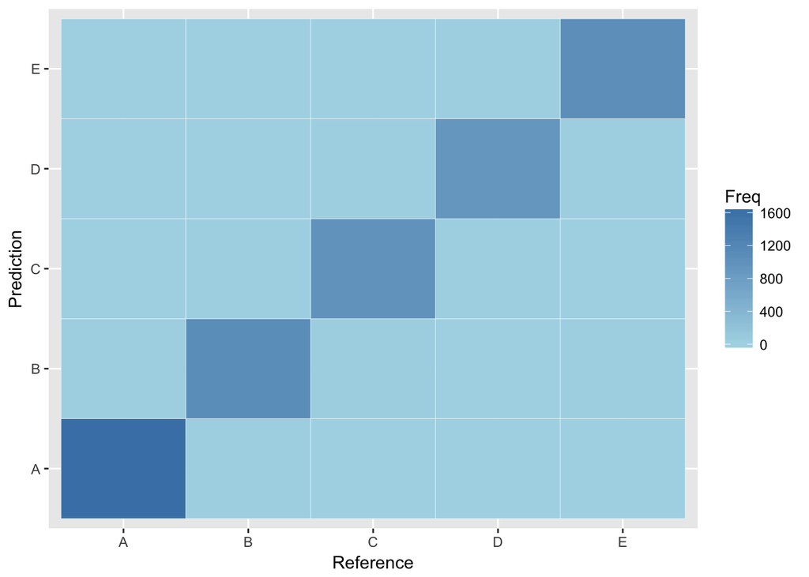

```r
z = data.frame(mtx$table)
p <- ggplot(data = z, aes(Reference, Prediction))
p <-  p + geom_tile(aes(fill = Freq), colour = "white")
p <-  p + scale_fill_gradient(low = "lightblue", high = "steelblue")
p
```

* The plot illustrates the accuracy of the prediction for each class.

## Prediction on Test dataset

The test dataset contains 20 rows. we will apply our model and calculate for the accuracy of our prediction. Note that this data dosent contain the labels to test the accuracy by direct comparison.

```r
predict(modFit, test)
```

[output not shown]

We get 19/20 predictions right with this model. (Which forms a part of the final assignment). That is 95% accuracy which **agrees with our error estimation**.

## Conclusion

We have used gradient boosting algorithm to train our dataset and classified the activities with 95% accuracy for the given test case.

## References

[1]http://groupware.les.inf.puc-rio.br/work.jsf?p1=11201 [2]http://statistics.berkeley.edu/sites/default/files/tech-reports/486.pdf